# Time-to-Event Endpoint Design (Cure Model)

# Overview

This report documents a group sequential design for a time-to-event endpoint and two treatment groups. The assumptions for the trial are that survival follows a Poisson mixture model which assumes a long-term survival (cure) rate. The Lachin and Foulkes method for sample size derivation is used along with standard group sequential assumptions for the asymptotic joint distribution of test statistics. Bounds are derived using the Lan-DeMets spending function methodology.

```r
library(gsDesign)
```

# Design assumptions

```r
# Number of analyses
k <- 4
# See gsDesign() help for description of boundary types
test.type <- 4
# 1-sided Type I error
alpha <- 0.025
# Type II error (1 - targeted power)
beta <- 0.1
# If test.type = 5 or 6, this sets maximum spending for futility
# under the null hypothesis. Otherwise, this is ignored.
astar <- 0
# Timing (information fraction) at interim analyses
timing <- c(0.3, 0.65, 0.9)
# Efficacy bound spending function
sfu <- sfLDOF
# Upper bound spending function parameters, if any
sfupar <- c(0)
# Lower bound spending function, if used (test.type > 2)
sfl <- sfHSD
# Lower bound spending function parameters, if any
sflpar <- c(-8)
# Assumed hazard ratio under alternate hypothesis
hr <- 0.72
# Null hypothesis hazard ratio
hr0 <- 1
# Dropout rate (exponential rate)
eta <- 0.01
# Enrollment rate (normally will be inflated to achieve power)
gamma <- c(2.5, 5, 7.5, 10)
# Relative enrollment rates by time period
R <- c(1.33333333333333, 1.33333333333333, 1.33333333333333, 14)
# Calendar time of final analysis
T <- 42
# Minimum follow-up time after enrollment complete
minfup <- 24
# Relative enrollment (experimental/placebo)
ratio <- 1
```

# Cure model parameters

```r
# This is used for inputting failure rate assumptions only
maxTime <- 42
# Assumed long-term survival rate
cureRate <- 0.7
# Survival rate at specific time
survRate <- 0.75
survRateTime <- 18
# Number of equally sized bins from 0 to maxTime to provide stepwise hazard rates
bins <- 20
# Compute theta for Poisson mixture cure rate model
theta <- -log(cureRate)
# Compute rate parameter lambda for Poisson mixture cure rate model
lambda <- -log(1 + log(survRate) / theta) / survRateTime
# Compute piecewise intervals for constant hazard approximation
ti <- (0:bins) / bins * maxTime
# Compute cumulative hazard based on actual Poisson mixture cure rate model
Hi <- theta * (1 - exp(-lambda * ti))
# Compute hazard rates corresponding to cumulative hazard rate assumptions
lambdaC <- (Hi[2:(bins + 1)] - Hi[1:bins]) / maxTime * bins
# Number of rate
len <- bins - 1
# equal length intervals for piecewise hazard rate approximation
S <- array(maxTime / bins, len)
```

- Control cure rate: 0.7
- Control survival rate at time 18: 0.75

# Derive fixed design

We derive sample size and event count requirements for a fixed design with a single analysis (no interim analysis).

```r
fixed_design <-
  nSurv(
    lambdaC = lambdaC,
    hr = hr,
    hr0 = hr0,
    eta = eta,
    gamma = gamma,
    R = R,
    S = S,
    T = T,
    minfup = minfup,
    ratio = ratio,
    alpha = alpha,
    beta = beta
  )
cat("Sample size:", ceiling(fixed_design$n), "Events: ", ceiling(fixed_design$d))
```

```
## Sample size: 1703 Events:  392
```

## Derive group sequential design

The following code derives the group sequential design using the method of Lachin and Foulkes.

```r
x <- gsSurv(
  k = k,
  test.type = test.type,
  alpha = alpha,
  beta = beta,
  astar = astar,
  timing = timing,
  sfu = sfu,
  sfupar = sfupar,
  sfl = sfl,
  sflpar = sflpar,
  lambdaC = lambdaC,
  hr = hr,
  hr0 = hr0,
  eta = eta,
  gamma = gamma,
  R = R,
  S = S,
  T = T,
  minfup = minfup,
  ratio = ratio
)
```

# Group sequential design summaries

## Textual design summary

A textual summary for the design is:

```r
cat(summary(x, timeunit = 'months'))
```

[output not shown]

## Tabular bound summary

The group sequential design boundaries and properties are summarized in the following table. We further describe the information as follows:

- The IA percent is the percent of statistical information (planned events) at the interim analysis relative to the final analysis. This matches the timing input.
- We note that while sample size (N) and events are rounded up in the table, the design stores continuous values for these numbers to exactly match the input timing of analyses. Thus, calculating with rounded up numbers in the table may not exactly match the IA % in the table.
- The calendar timing of the analysis is the expected timing relative to opening of enrollment.
- Z-values are for standard normal test statistics with positive values representing a treatment benefit for the experimental group.
- p-values are nominal p-values corresponding to the Z-values.
- ~HR at bound is an asymptotic approximation for the hazard ratio required to cross a bound. This is not a criterion that must be met for Type I error control.
- P(Cross) if HR=1 is the cumulative probability of crossing a bound (efficacy or futility) at or before a given analysis. We note that for the default non-binding Type I error option that P(Cross) if HR=1 will be less than the specified Type I error. This is because Type I error is computed ignoring the futility bound since it is advisory only. The actual cumulative Type I error spending is 4.3^{-5}, 0.005434, 0.018145, 0.025.
- P(Cross) if HR=0.72 is the cumulative probability of crossing a bound under the alternate hypothesis.

```r
gsBoundSummary(x, ratio = 1, digits = 4, ddigits = 2, tdigits = 1, timename = 'Month')
```

```
##     Analysis               Value Efficacy Futility
##    IA 1: 30%                   Z   3.9286  -1.5950
##      N: 1196         p (1-sided)   0.0000   0.9446
##  Events: 122        ~HR at bound   0.4904   1.3355
##  Month: 12.9    P(Cross) if HR=1   0.0000   0.0554
##              P(Cross) if HR=0.72   0.0169   0.0003
##    IA 2: 65%                   Z   2.5479   0.1379
##      N: 1762         p (1-sided)   0.0054   0.4451
##  Events: 264        ~HR at bound   0.7305   0.9831
##    Month: 20    P(Cross) if HR=1   0.0054   0.5562
##              P(Cross) if HR=0.72   0.5438   0.0060
##    IA 3: 90%                   Z   2.1325   1.4238
##      N: 1762         p (1-sided)   0.0165   0.0772
##  Events: 365        ~HR at bound   0.7998   0.8615
##  Month: 29.6    P(Cross) if HR=1   0.0181   0.9231
##              P(Cross) if HR=0.72   0.8443   0.0449
##        Final                   Z   2.0656   2.0656
##      N: 1762         p (1-sided)   0.0194   0.0194
##  Events: 406        ~HR at bound   0.8145   0.8145
##    Month: 42    P(Cross) if HR=1   0.0247   0.9753
##              P(Cross) if HR=0.72   0.9000   0.1000
```

# Other design characteristics

## Design plot: Hazard ratio

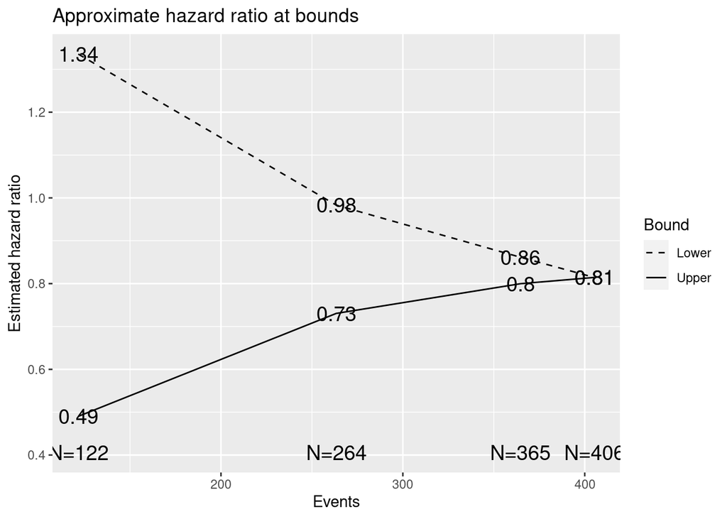

```r
plot(x, plottype = 8, xlab = 'Events', ylab = 'Estimated hazard ratio')
```

## Underlying survival

Following is a plot of the assumed control and experimental survival curves under the alternate hypothesis assumptions over the planned course of the trial.

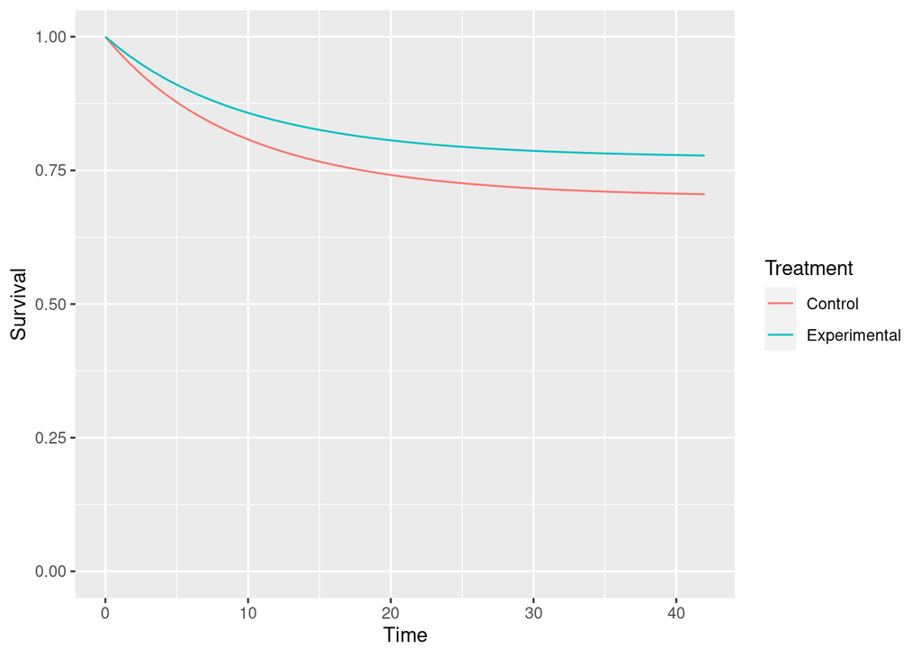

```r
xtime <- (0:50) / 50 * max(x$T)
control_survival <- exp(-theta * (1 - exp(-lambda * xtime)))
df <- rbind(
  data.frame(Treatment = "Control", Time = xtime, Survival = control_survival),
  data.frame(Treatment = "Experimental", Time = xtime, Survival = control_survival^hr)
)
ggplot(df, aes(x = Time, y = Survival, col = Treatment)) +
  geom_line() +
  ylim(0, 1)
```

## Sample size and event accrual

Following is a plot of expected accrual of subjects and events over time under design assumptions for the alternate hypothesis.

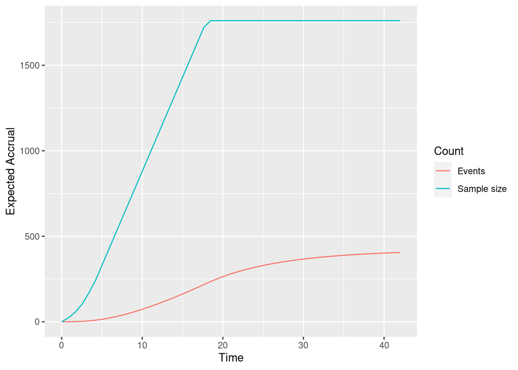

```r
accrual_fn <- function(Time, x) {
  xx <- nEventsIA(tIA = Time, x = x, simple = FALSE)
  data.frame(
    Time = Time,
    Accrual = c(xx$eNC + xx$eNE, xx$eDC + xx$eDE),
    Count = c("Sample size", "Events")
  )
}
accrual <- data.frame(Time = 0, Accrual = c(0, 0), Count = c("Sample size", "Events"))

for (i in seq_along(xtime[xtime > 0])) {
  accrual <- rbind(accrual, accrual_fn(Time = xtime[i + 1], x = x))
}

ggplot(accrual, aes(x = Time, y = Accrual, col = Count)) +
  geom_line() +
  ylab("Expected Accrual")
```

# Environment information

- Run date: 2021-11-23 22:18:46
- R version: R version 4.0.1 (2020-06-06)
- gsDesign version: 3.2.1.9000